# Comparación de varias medias con los datos del Barómetro de las Américas

Arturo Maldonado

4/28/2021

# Introducción

En este documento veremos como construir intervalos de confianza de la media usando los datos del Barómetro de las Américas para más de dos grupos. Para eso, vamos a seguir usando el último informe regional “El pulso de la democracia,” disponible [aquí](https://www.vanderbilt.edu/lapop/ab2018/2018-19_AmericasBarometer_Regional_Report_Spanish_W_03.27.20.pdf), donde se presentan los principales hallazgos de la ronda 2018/19 del Barómetro de las Américas. Una de las secciones de este informe, reporta los resultados acerca del apoyo a la democracia electoral. En particular, el gráfico 1.2 muestra el apoyo promedio a la democracia según países. Este tipo de gráficos es uno de los más usados con los datos del Barómetro de las Américas pues usa al máximo los resultados de un ronda, presentando una visión panorámica de la región para una variable crítica como el apoyo a la democracia para 18 países en América Latina.

# Sobre la base de datos

Los datos que vamos a usar deben citarse de la siguiente manera: Fuente: Barómetro de las Américas por el Proyecto de Opinión Pública de América Latina (LAPOP), wwww.LapopSurveys.org. Pueden descargar los datos de manera libre [aquí](http://datasets.americasbarometer.org/database/login.php). En este enlace, se pueden registrar o entrar como “Free User.” En el buscador, se puede ingresar el texto “2018.” Ahí se tendrá acceso a la base de datos completa “2018 LAPOP AmericasBarometer Merge_v1.0.dta” en versión para STATA. Se descarga la base de datos en formato zip, la que se descomprime en formato .dta. Una vez descargada y guardada en el directorio de trabajo, se tiene que leer la base de datos como un objeto dataframe en R.

En este documento se carga una base de datos recortada, originalmente en formato SPSS (.sav). Esta base de datos se encuentra alojada en el repositorio “materials_edu” de la cuenta de LAPOP en GitHub. Mediante la librería `rio` y el comando `import` se puede importar esta base de datos desde este repositorio. Además, se seleccionan los datos de países con códigos menores o iguales a 35, es decir, se elimina las observaciones de Estados Unidos y Canadá.

```r
library(rio)
lapop18 <- import("https://raw.github.com/lapop-central/materials_edu/main/LAPOP_AB_Merge_2018_v1.0.sav")
lapop18 <- subset(lapop18, pais<=35)
```

# Apoyo a la democracia según países

El gráfico 1.2 del reporte muestra el promedio del apoyo a la democracia electoral para cada uno de los 18 países analizados. Presenta, además, los intervalos de confianza por cada país, en forma de una barra gris, que indica el intervalo inferior y superior de este intervalo, con un punto que indica el valor de la media.

Para reproducir, los datos de este gráfico, primero se tiene que recodificar la variable, de la misma manera que se hizo en la sección sobre [intervalos de confianza](https://arturomaldonado.github.io/BarometroEdu_Web/IC.html).

```r
library(dplyr)
library(car)
lapop18$ing4r <- recode(lapop18$ing4, "1:4=0; 5:7=100")
table(lapop18$ing4r)
```

```
##
##     0   100
## 11463 15623
```

Cuando se importa la base de datos, las variables son definidas como numéricas, siendo que muchas de ellas son factores, como la variable “pais.” Para poder evaluar el apoyo a la democracia según países, se va a definir una nueva variable “paises” como factor y se va a etiquetar.

```r
lapop18$paises <- as.factor(lapop18$pais)
levels(lapop18$paises) <- c("México", "Guatemala", "El Salvador", "Honduras", "Nicaragua",
                            "Costa Rica", "Panamá", "Colombia", "Ecuador", "Bolivia", "Perú",
                            "Paraguay", "Chile", "Uruguay", "Brasil", "Argentina", "Rep. Dom.",
                            "Jamaica")
table(lapop18$paises)
```

```
##
##      México   Guatemala El Salvador    Honduras   Nicaragua  Costa Rica
##        1580        1596        1511        1560        1547        1501
##      Panamá    Colombia     Ecuador     Bolivia        Perú    Paraguay
##        1559        1663        1533        1682        1521        1515
##       Chile     Uruguay      Brasil   Argentina   Rep. Dom.     Jamaica
##        1638        1581        1498        1528        1516        1513
```

Con estas variables, se crea un nuevo dataframe con los datos del promedio (que es la proporción) de apoyo a la democracia por cada país, con los datos para construir los intervalos de confianza. Para esto usamos el comando `summarySE` que es parte de la librería `Rmisc`. Estos datos se guardan en el dataframe “df.”

```r
library(Rmisc)
df <- summarySE(data=lapop18, measurevar="ing4r", groupvar="paises", na.rm=T)
df
```

```
##         paises    N    ing4r       sd       se       ci
## 1       México 1513 62.72307 48.37013 1.243534 2.439235
## 2    Guatemala 1524 48.88451 50.00396 1.280890 2.512496
## 3  El Salvador 1465 58.56655 49.27750 1.287448 2.525440
## 4     Honduras 1493 45.01005 49.76705 1.287989 2.526461
## 5    Nicaragua 1496 51.53743 49.99307 1.292540 2.535385
## 6   Costa Rica 1458 72.35940 44.73735 1.171633 2.298267
## 7       Panamá 1537 53.80612 49.87115 1.272074 2.495186
## 8     Colombia 1619 59.78999 49.04734 1.218967 2.390921
## 9      Ecuador 1512 54.43122 49.81973 1.281225 2.513169
## 10     Bolivia 1630 49.14110 50.00796 1.238641 2.429496
## 11        Perú 1496 49.26471 50.01131 1.293012 2.536310
## 12    Paraguay 1478 51.21786 50.00208 1.300621 2.551262
## 13       Chile 1550 63.87097 48.05295 1.220546 2.394097
## 14     Uruguay 1529 76.19359 42.60379 1.089543 2.137158
## 15      Brasil 1471 59.82325 49.04221 1.278685 2.508243
## 16   Argentina 1495 71.10368 45.34325 1.172714 2.300340
## 17   Rep. Dom. 1474 59.22659 49.15800 1.280400 2.511601
## 18     Jamaica 1346 51.18871 50.00445 1.362969 2.673777
```

Con este nuevo dataframe, se construye un gráfico similar al Gráfico 1.2 del reporte. Se tiene que tomar en cuenta que algunos porcentajes no son similares a los mostrados en el reporte porque este código no incluye el factor de expansión.

Para la construcción del gráfico se ha usado la librería `ggplot2`. El comando `ggplot` requiere primero especificar el dataframe con el que se trabaja, que en este caso es “df.” Luego, se define la “estética” del gráfico con la especificación `aes`, donde se especifica qué información se incluirá en cada eje. Se parte de que las barras serán verticales, por lo que en el eje X se define la variable “paises,” pero se usa la especificación `reorder` para indicar que las barras no sigan el orden de la variable “paises” sino que vayan ordenadas por los valores de la variable “ing4r.” En el eje Y se define la variable “ing4r” que marcará la altura de la barra.

Una vez definidos los ejes, se usa el comando `geom_bar` para indicar que se va a crear un gráfico de barras. Dentro de este comando se especifica el ancho, el color interno, el color del borde y, sobre todo, que se use los datos del dataframe “df” tal como aparecen, con la especificación `stat="identity"`.

Además de la barra, se agrega `goem_errorbar` para incluir las barras de error que mancan los límites de los intervalos de confianza. Esta capa también requiere na estética `aes` donde se define los límites inferior (`ymin=ing4r-ci`) y superior (`ymax=ing4r+ci`).

Se usa `geom_text` para añadir las etiquetas de datos a cada barra. Esta especificación requiere una estética `aes` donde se define que se usará el dato de “ing4r,” pero redondeado a 1 decimal y con el símbolo “%.” Se ajusta la posición de la etiqueta con `hjust` y el tamaño de la etiqueta con `size`.

Finalmente, se indica que el eje X no tenga una etiqueta y que el eje Y se nombre como "Apoyo a la democracia según países. Se usa la especificación `coord_flip()` para girar el gráfico 90 grados y presentar las barras horizontales.

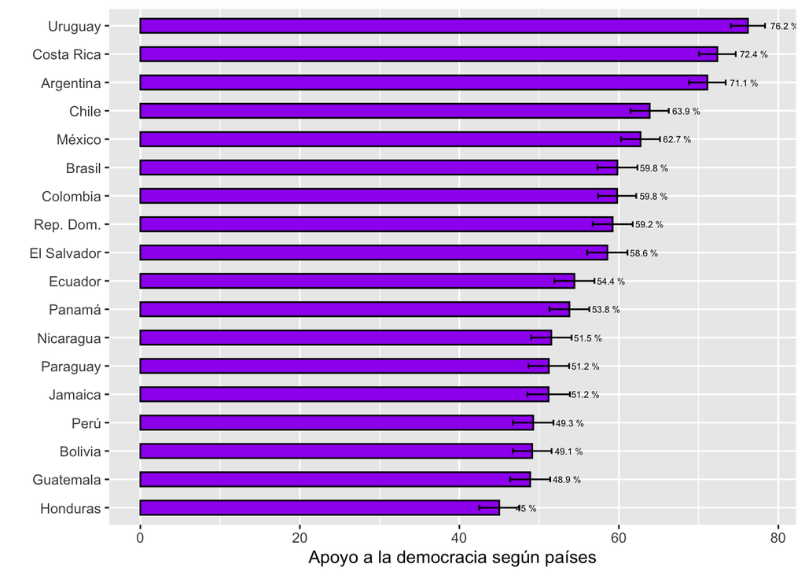

```r
library(ggplot2)
graf1 <- ggplot(df, aes(x=reorder(paises, ing4r), y=ing4r))+
  geom_bar(width=0.5, fill="purple", colour="black", stat="identity")+
  geom_errorbar(aes(ymin=ing4r-ci, ymax=ing4r+ci), width=0.2)+
  geom_text(aes(label=paste(round(ing4r, 1), "%")), hjust=-0.8, size=2)+
  xlab("")+
  ylab("Apoyo a la democracia según países")+
  coord_flip()
graf1
```

# Considerando el factor de expansión

```r
library(descr)
df2 <- as.data.frame(compmeans(lapop18$ing4r, lapop18$paises, lapop18$weight1500, plot=F))
df2
```

```
##                 Mean     N Std. Dev.
## México      62.72307  1436  48.37099
## Guatemala   48.88451  1432  50.00501
## El Salvador 58.56655  1454  49.27762
## Honduras    45.01005  1436  49.76772
## Nicaragua   51.53743  1451  49.99359
## Costa Rica  72.35940  1457  44.73736
## Panamá      53.80612  1479  49.87179
## Colombia    59.78999  1460  49.04899
## Ecuador     54.43122  1479  49.82010
## Bolivia     49.14110  1454  50.00983
## Perú        49.26471  1475  50.01155
## Paraguay    51.21786  1463  50.00225
## Chile       63.87097  1419  48.05438
## Uruguay     76.19359  1451  42.60454
## Brasil      59.99750  1470  49.00697
## Argentina   71.10368  1468  45.34353
## Rep. Dom.   59.22659  1458  49.15818
## Jamaica     51.18871  1334  50.00461
## Total       57.71191 26078  49.40263
```

Este comando calcula la media, el N y la desviación estándar de una variable por cada grupo de otra variable. Para reproducir el gráfico de barras, se requiere partir de estos datos y calcular el error estándar y el intervalo de confianza y agregar estos datos al dataframe como nuevas columnas.

En primer lugar, se crea un vector con los nombres que asignaremos a las columnas, las que asignamos con el comando `colnames`. Luego, el comando `compmeans` no crea una columna con los nombres de los países, por lo que se tiene que agregar con el comando `row.names`. Finalmente, se crea una nueva columna con los datos del error estándar y el intervalo de confianza.

```r
varnames <- c("media", "n", "sd")
colnames(df2) <- varnames
df2$pais <- row.names(df2)
df2$err.st <- df2$sd/sqrt(df2$n)
df2$ci <- df2$err.st*1.96
df2
```

```
##                media     n       sd        pais    err.st        ci
## México      62.72307  1436 48.37099      México 1.2764616 2.5018646
## Guatemala   48.88451  1432 50.00501   Guatemala 1.3214236 2.5899902
## El Salvador 58.56655  1454 49.27762 El Salvador 1.2923124 2.5329324
## Honduras    45.01005  1436 49.76772    Honduras 1.3133198 2.5741069
## Nicaragua   51.53743  1451 49.99359   Nicaragua 1.3124436 2.5723894
## Costa Rica  72.35940  1457 44.73736  Costa Rica 1.1720349 2.2971884
## Panamá      53.80612  1479 49.87179      Panamá 1.2967936 2.5417155
## Colombia    59.78999  1460 49.04899    Colombia 1.2836708 2.5159947
## Ecuador     54.43122  1479 49.82010     Ecuador 1.2954495 2.5390809
## Bolivia     49.14110  1454 50.00983     Bolivia 1.3115147 2.5705687
## Perú        49.26471  1475 50.01155        Perú 1.3021897 2.5522918
## Paraguay    51.21786  1463 50.00225    Paraguay 1.3072764 2.5622617
## Chile       63.87097  1419 48.05438       Chile 1.2756800 2.5003328
## Uruguay     76.19359  1451 42.60454     Uruguay 1.1184645 2.1921904
## Brasil      59.99750  1470 49.00697      Brasil 1.2782012 2.5052744
## Argentina   71.10368  1468 45.34353   Argentina 1.1834565 2.3195747
## Rep. Dom.   59.22659  1458 49.15818   Rep. Dom. 1.2874105 2.5233246
## Jamaica     51.18871  1334 50.00461     Jamaica 1.3690903 2.6834171
## Total       57.71191 26078 49.40263       Total 0.3059236 0.5996102
```

Con este nuevo dataframe “df2,” que ya incluye el valor del intervalo de confianza, se puede reproducir el Gráfico 1.2, de manera muy similar al gráfico anterior.

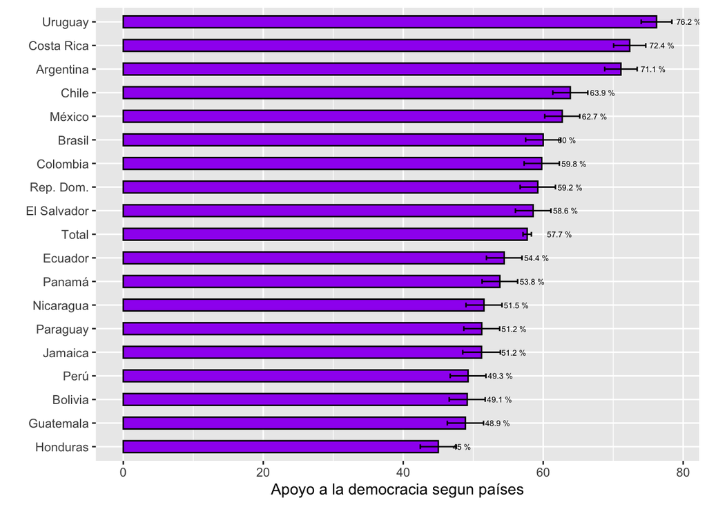

```r
graf2 <- ggplot(df2, aes(x=reorder(pais, media), y=media))+
  geom_bar(width=0.5, fill="purple", colour="black", stat="identity")+
  geom_errorbar(aes(ymin=media-ci, ymax=media+ci), width=0.2)+
  geom_text(aes(label=paste(round(media, 1), "%")), hjust=-0.8, size=2)+
  xlab("")+
  ylab("Apoyo a la democracia segun países")+
  coord_flip()
graf2
```

Este estilo de gráficos es bastante usado en los reportes del Barómetro de las Américas y otros elaborados por LAPOP. Este gráfico muestra el valor promedio del apoyo a la democracia en cada país y una barra con los intervalos de confianza al 95%. De esta manera, se puede hacer una comparación visual entre los países para saber donde podría haber diferencias estadísticamente significativas. Cuando los intervalos de confianza de dos países se intersectan, no se puede decir que haya una diferencia en el promedio poblacional del apoyo a la democracia. De otro lado, si los intervalos de confianza no se intersectan, se podría decir que hay una diferencia poblacional en el promedio de apoyo a la democracia entre los países comparados.

Si, por ejemplo, se compara el apoyo a la democracia promedio entre Uruguay (76.2%) y Costa Rica (72.4%), los países arriba en la clasificación, no se podría decir que los promedios poblacionales de ambos países son diferentes pues los intervalos de confianza se intersectan. Por el contrario, si se compara Argentina (71.1%) y Chile (63.9), se podría decir que el promedio poblacional de apoyo a la democracia en Argentina es mayor que el equivalente en Chile, pues ambos intervalos de confianza no se intersectan.

Sin embargo, esta comparación visual es un “heurístico,” pues para saber si hay diferencias estadísticamente significativas entre los países (o entre un par de países) se tiene que hacer una prueba estadística. En el documento sobre la [la comparación de 2 medias](https://arturomaldonado.github.io/BarometroEdu_Web/pruebat.html), se uso la prueba t para comparar dos grupos. Se podría usar este mismo test para comparar si las diferencias en las medias muestrales entre dos países son extrapolables, pero no ayuda si se quisiera tener una comparación general entre todo este grupo de países, o sería muy engorroso tener que hacer las múltiples comparaciones para cada pareja de países.

Para poder tener ese panorama general y, a su vez, poder evaluar los emparejamientos se puede usar otra prueba estadística.

# Test de ANOVA

El test de ANOVA sirve para comparar la media (o la proporción de una variable dummy) de una variable dependiente numérica (como apoyo a la democracia) entre grupos de una variable de tipo factor (con más de 2 grupos, como “pais”).

Esta prueba se basa en la distribución F y propone la siguiente hipótesis nula para la comparación de una variable numérica X entre n grupos de la variable de factor.

$$H0: \mu_{x1} = \mu_{x2} = \mu_{x1} =...= \mu_{xn}$$

La hipótesis alternativa que propone es que al menos una media poblacional de un grupo es diferente.

# Evaluando las medias mediante ANOVA

El comando `aov` realiza el análisis de varianza con una variable dependiente numérica y una variable independiente de tipo factor con más de 2 grupos. Esta prueba se guarda en un objeto “anova” para luego describir los resultados con el comando `summary`.

```r
anova <- aov(lapop18$ing4r~ lapop18$paises)
summary(anova)
```

```
##                   Df   Sum Sq Mean Sq F value Pr(>F)
## lapop18$paises    17  2020430  118849   50.19 <2e-16 ***
## Residuals      27068 64097287    2368
## ---
## Signif. codes:  0 '***' 0.001 '**' 0.01 '*' 0.05 '.' 0.1 ' ' 1
## 956 observations deleted due to missingness
```

El valor del estadístico de la prueba F es 50.19, con un correspondiente p-value muy pequeño. Como este valor del p-value es menor de 0.05, se puede rechazar la hipótesis nula y afirmar que al menos una media poblacional es diferente. El test de ANOVA no nos indica cuáles medias son diferentes.

Para averiguar qué medias son diferentes, se tiene que evaluar los diferentes emparejamientos para saber las diferencias en cada pareja. Este detalle se puede calcular con una prueba post-hoc llamada Test de Tukey. En R este test se puede correr con el comando `TukeyHSD`.

El resultado que nos brinda es la realización de una prueba t en cada pareja de países. En este caso como se tiene 18 países, las parejas son muchas. En cada emparejamiento se tiene el valor de la diferencia de la variable “ing4r” entre los 2 países, así como el límite inferior y superior de esta diferencia. Se tiene que evaluar el p-value ajustado (“p adj”) para saber si la diferencia en el apoyo a la democracia entre esos dos países es estadísticamente significativo y extrapolable a la población.

Por ejemplo, habíamos encontrado visualmente los intervalos de confianza del apoyo a la democracia entre Uruguay y Costa Rica se intersectaban, por lo que probablemente no había diferencias significativas. El test de Tukey indica que el p-value de este emparejamiento (0.785) es mayor a 0.05, por lo que efectivamente no se puede decir que haya diferencias poblacionales en el apoyo a la democracia entre estos dos países.

También habíamos visto que los intervalos de confianza del apoyo a la democracia entre Argentina y Chile no se intersectaban, por lo que se intuía que había una diferencia significativa. El test de Tukey muestra un p-value de 0.0053, menor de 0.05, por lo que se puede afirmar que existe una diferencia estadísticamente significativa en el apoyo a la democracia entre estos dos países a un 95% de confianza.

```r
TukeyHSD(anova)
```

```
##   Tukey multiple comparisons of means
##     95% family-wise confidence level
##
## Fit: aov(formula = lapop18$ing4r ~ lapop18$paises)
##
## $`lapop18$paises`
##                                diff          lwr         upr     p adj
## Guatemala-México       -13.83855232 -19.99973268  -7.6773720 0.0000000
## El Salvador-México      -4.15651385 -10.37919495   2.0661672 0.6610391
## Honduras-México        -17.71301987 -23.90598442 -11.5200553 0.0000000
## Nicaragua-México       -11.18563360 -17.37547195  -4.9957953 0.0000000
## Costa Rica-México        9.63632968   3.40606390  15.8665955 0.0000102
## Panamá-México           -8.91695094 -15.06513692  -2.7687650 0.0000619
## Colombia-México         -2.93307293  -9.00353098   3.1373851 0.9695508
## Ecuador-México          -8.29184982 -14.46519846  -2.1185012 0.0003980
## Bolivia-México         -13.58196246 -19.64251748  -7.5214074 0.0000000
## Perú-México            -13.45836087 -19.64819922  -7.2685225 0.0000000
## Paraguay-México        -11.50520478 -17.71396660  -5.2964430 0.0000000
## Chile-México             1.14790099  -4.98748174   7.2832837 0.9999999
## Uruguay-México          13.47052383   7.31436420  19.6266835 0.0000000
## Brasil-México           -2.89981726  -9.11604738   3.3164129 0.9784115
## Argentina-México         8.38061217   2.18973298  14.5714914 0.0003337
## Rep. Dom.-México        -3.49647245  -9.70949428   2.7165494 0.8866710
## Jamaica-México         -11.53435947 -17.89525932  -5.1734596 0.0000000
## El Salvador-Guatemala    9.68203847   3.47041480  15.8936621 0.0000081
## Honduras-Guatemala      -3.87446755 -10.05632152   2.3073864 0.7629801
## Nicaragua-Guatemala      2.65291872  -3.52580342   8.8316409 0.9909291
## Costa Rica-Guatemala    23.47488200  17.25566016  29.6941038 0.0000000
## Panamá-Guatemala         4.92160137  -1.21539295  11.0585957 0.3140668
## Colombia-Guatemala      10.90547939   4.84635656  16.9646022 0.0000001
## Ecuador-Guatemala        5.54670250  -0.61550019  11.7089052 0.1398789
## Bolivia-Guatemala        0.25658986  -5.79261139   6.3057911 1.0000000
## Perú-Guatemala           0.38019145  -5.79853069   6.5589136 1.0000000
## Paraguay-Guatemala       2.33334754  -3.86433201   8.5310271 0.9980099
## Chile-Guatemala         14.98645331   8.86228563  21.1106210 0.0000000
## Uruguay-Guatemala       27.30907615  21.16409365  33.4540586 0.0000000
## Brasil-Guatemala        10.93873505   4.73357386  17.1438962 0.0000001
## Argentina-Guatemala     22.21916449  16.03939963  28.3989294 0.0000000
## Rep. Dom.-Guatemala     10.34207987   4.14013269  16.5440270 0.0000009
## Jamaica-Guatemala        2.30419285  -4.04589026   8.6542759 0.9987355
```

[output cut: 105 more lines]

```
## Uruguay-Chile           12.32262284   6.20350627  18.4417394 0.0000000
## Brasil-Chile            -4.04771825 -10.22726542   2.1318289 0.6944042
## Argentina-Chile          7.23271119   1.07866605  13.3867563 0.0053246
## Rep. Dom.-Chile         -4.64437344 -10.82069326   1.5319464 0.4358759
## Jamaica-Chile          -12.68226046 -19.00731644  -6.3572045 0.0000000
## Brasil-Uruguay         -16.37034109 -22.57051716 -10.1701650 0.0000000
## Argentina-Uruguay       -5.08991165 -11.26467089   1.0848476 0.2661992
## Rep. Dom.-Uruguay      -16.96699628 -23.16395575 -10.7700368 0.0000000
## Jamaica-Uruguay        -25.00488330 -31.35009514 -18.6596715 0.0000000
## Argentina-Brasil        11.28042944   5.04577891  17.5150800 0.0000000
## Rep. Dom.-Brasil        -0.59665519  -6.85329344   5.6599831 1.0000000
## Jamaica-Brasil          -8.63454221 -15.03805131  -2.2310331 0.0003647
## Rep. Dom.-Argentina    -11.87708463 -18.10853635  -5.6456329 0.0000000
## Jamaica-Argentina      -19.91497165 -26.29387416 -13.5360691 0.0000000
## Jamaica-Rep. Dom.       -8.03788702 -14.43828171  -1.6374923 0.0016139
```

# Resumen

En esta sección se ha expandido la comparación de medias de 2 grupos a más de 2 grupos. En primer lugar, se realizó una exploración visual, mediante un gráfico de barras con intervalos de confianza. Luego, se formalizó estas comparaciones con el test de ANOVA y con la prueba post-hoc de Tukey que permite evaluar cada emparejamiento entre grupos y saber si hay diferencias estadísticamente significativas.